# Anomaly Analysis for Grain Boundary Visual Search (E3)

Dave Braun

November 12, 2021

*This document was last updated at 2022-03-21 13:41:47.*

This is a space where we’ll explore some of the effects related to the presence absence of the anomaly, which is simply just one inner hexagon boundary that’s randomly chosen to be missing on 30% of trials. The lines that were selected to be among the anomalies were a subset of the total lines, mostly clustered in the middle of the array to minimize the number of lines that border the “larger grain” that also fell on the exterior of the whole array.

**Sample size = 32.**

**Things to look at:**

1. Start with just a simple analysis looking at whether there was a bias to be attracted to or averse to boundaries surrounding the larger grain relative to those other boundaries.

# 1. Simple anomaly analysis

Need to start with some of the basic preprocessing that’s been done in the usual eda analyses, which involves summarizing which lines were selected on each trial.

```r
source('../compute_accuracy_columns.r')

d <- compute_accuracy_columns(d, thinnest_lines)
```

```r
compute_selected_lines <- function(data){
  participant <- data$participant[1]
  trial <- data$trial_count[1]

  selected_lines <- c(NA, NA, NA)
  indices <- c(NA, NA, NA)
  for (row in 1:(nrow(data))) {
    if (data[row,]$selected_or_released == 'selected') {
      slot <- which(is.na(selected_lines))[1]
      selected_lines[slot]<- data[row,]$line_id
      indices[slot] <- row
    } else if (data[row,]$selected_or_released == 'released'){
      slot <- which(!(is.na(selected_lines)) & selected_lines == data[row,]$line_id)
      selected_lines[slot] <- NA
      indices[slot] <- NA
    }
  }

  return(selected_lines)

}




trial_summary <- data.frame(participant = vector(), trial = vector(), is_anomaly_trial = vector(), anomaly_line_id = vector(), anomaly_group = vector(), selected_line_1 = vector(), selected_line_2 = vector(), selected_line_3 = vector())

for (participant in sapply(unique(d$participant), as.integer)) {
  for (trial in sapply(unique(d[d$participant == participant,]$trial_count), as.integer)) {
    selected_lines <- compute_selected_lines(d[d$participant == participant & d$trial_count == trial,])
    is_anomaly_trial <- d[d$participant == participant & d$trial_count == trial,]$is_anomaly_trial[1]
    anomaly_line_id <- d[d$participant == participant & d$trial_count == trial,]$anomaly_line_id[1]
    anomaly_group <- d[d$participant == participant & d$trial_count == trial,]$anomaly_group[1]
    trial_summary <- rbind(trial_summary, data.frame(participant = participant, trial = trial, is_anomaly_trial = is_anomaly_trial, anomaly_line_id = anomaly_line_id, anomaly_group = anomaly_group,
                                                     selected_line_1 = selected_lines[1], selected_line_2 = selected_lines[2], selected_line_3 = selected_lines[3]))
  }
}

head(trial_summary)
```

|  | participant | trial | is_anomaly_trial | anomaly_line_id | anomaly_group | selected_line_1 | selected_line_2 | selected_line_3 |
| --- | --- | --- | --- | --- | --- | --- | --- | --- |
| 1 | 59 | 0 | False |  | NA | r0c0_bottom_right | r0c2_bottom_left | r2c3_bottom_left |
| 2 | 59 | 1 | False |  | NA | r2c3_bottom_left | r2c2_bottom_right | r0c3_bottom_left |
| 3 | 59 | 2 | False |  | NA | r2c2_bottom_left | r2c1_bottom_right | r1c1_right |
| 4 | 59 | 4 | False |  | NA | r0c3_bottom_right | r0c2_bottom_left | r0c1_bottom_left |
| 5 | 59 | 5 | False |  | NA | r2c3_bottom_left | r1c2_bottom_right | r0c1_bottom_right |
| 6 | 59 | 6 | False |  | NA | r2c3_bottom_left | r1c2_bottom_right | r0c0_right |

```python
import pandas as pd
import pickle
import sys

trial_summary = pd.DataFrame(r.trial_summary)
trial_summary_dict = trial_summary.to_dict('records')

with open('contiguous_dict.pickle', 'rb') as file:
  contiguous_dict = pickle.load(file)



trial_summary_start = [x for x in trial_summary_dict if x['is_anomaly_trial'] == 'True']
trial_summary_end = []


for trial in trial_summary_start:
  num_contiguous = 0
  for i in range(1,4):
    if trial['selected_line_{}'.format(i)] in contiguous_dict[trial['anomaly_line_id']]:
      num_contiguous += 1
  trial['num_contiguous'] = num_contiguous
  trial_summary_end.append(trial)

trial_summary = pd.DataFrame(trial_summary_end)
```

```r
trial_summary_all <- trial_summary
trial_summary = py$trial_summary
trial_summary$num_non_contiguous <- 3 - trial_summary$num_contiguous
head(trial_summary)
```

|  | participant | trial | is_anomaly_trial | anomaly_line_id | anomaly_group | selected_line_1 | selected_line_2 | selected_line_3 | num_contiguous | num_non_contiguous |
| --- | --- | --- | --- | --- | --- | --- | --- | --- | --- | --- |
| 1 | 59 | 7 | True | r1c1_bottom_right | 0 | r2c3_bottom_left | r2c2_bottom_left | r0c2_bottom_right | 1 | 2 |
| 2 | 59 | 10 | True | r0c2_bottom_right | 2 | r2c0_bottom_right | r0c1_bottom_right | r0c3_bottom_left | 1 | 2 |
| 3 | 59 | 12 | True | r0c1_bottom_right | 2 | r1c1_right | r2c1_bottom_left | r0c2_bottom_right | 1 | 2 |
| 4 | 59 | 14 | True | r2c2_bottom_right | 2 | r1c2_bottom_right | r0c1_bottom_left | r1c0_bottom_right | 0 | 3 |
| 5 | 59 | 18 | True | r1c1_bottom_right | 0 | r2c3_bottom_left | r0c2_bottom_right | r0c2_right | 0 | 3 |
| 6 | 59 | 24 | True | r0c2_bottom_right | 2 | r3c1_right | r2c2_right | r1c3_bottom_left | 0 | 3 |

```r
total_inner_lines <- nrow(line_data[line_data$participant == 59 & line_data$trial_count == 0 & line_data$is_exterior != 'True',])
total_trials <- nrow(trial_summary)
non_big_grain_lines_0 <- (total_inner_lines - 10 - 1) * total_trials
big_grain_lines_0 <- (10) * total_trials
non_big_grain_lines_1 <- (total_inner_lines - 9 - 1) * total_trials
big_grain_lines_1 <- 9 * total_trials
non_big_grain_lines_2 <- (total_inner_lines - 8 - 1) * total_trials
big_grain_lines_2 <- 8 * total_trials

results <- data.frame(expected = vector(), observed = vector(), group = vector())

for (group in 0:2){
  expected <- c(eval(as.name(paste0('non_big_grain_lines_', group))), eval(as.name(paste0('big_grain_lines_', group))))
  observed <- c(sum(trial_summary[trial_summary$anomaly_group == group,]$num_non_contiguous), sum(trial_summary[trial_summary$anomaly_group == group,]$num_contiguous))
  print(c(expected, observed))
  #results[paste0('test', group)] <- chisq.test(expected, observed)
  results <- rbind(results, data.frame(expected_non = expected[1], expected_anomaly = expected[2], observed_non = observed[1], observed_anomaly = observed[2], group = group))
}
```

```
## [1] 19272  8760   578   274
## [1] 20148  7884   433   215
## [1] 21024  7008   843   285
```

```r
results
```

| expected_non | expected_anomaly | observed_non | observed_anomaly | group |
| --- | --- | --- | --- | --- |
| 19272 | 8760 | 578 | 274 | 0 |
| 20148 | 7884 | 433 | 215 | 1 |
| 21024 | 7008 | 843 | 285 | 2 |

**Overall count**

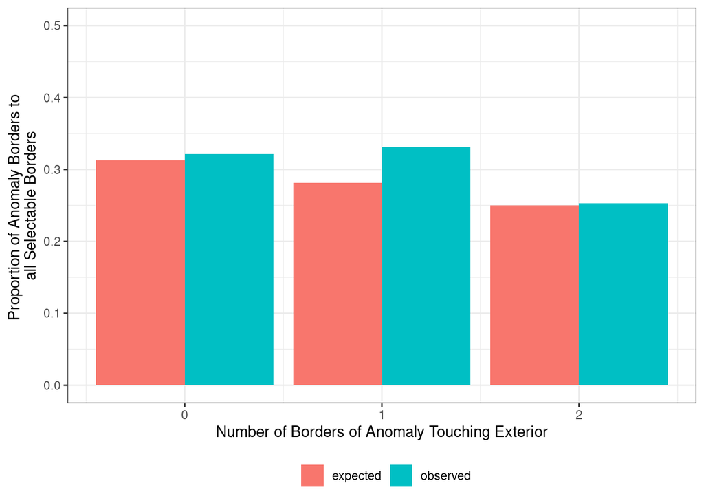

```r
results$expected_proportion <- results$expected_anomaly / (results$expected_non + results$expected_anomaly)
results$observed_proportion <- results$observed_anomaly / (results$observed_non + results$observed_anomaly)

plot_data <- results %>%
  select(group, expected_proportion, observed_proportion) %>%
  gather(var, value, expected_proportion, observed_proportion)

plot_data %>%
  mutate(var = recode(var, 'expected_proportion' = 'expected', 'observed_proportion' = 'observed')) %>%
  ggplot(aes(x = group, y = value, group = var)) +
  geom_bar(stat = 'identity', aes(fill = var), position = position_dodge(width = .9)) +
  ylim(0, .5) +
  labs(
    x = 'Number of Borders of Anomaly Touching Exterior',
    y = 'Proportion of Anomaly Borders to \nall Selectable Borders',
    fill = ''
  ) +
  theme_bw() +
  theme(legend.position = 'bottom')
```

```r
ggsave('basic_anomaly_result.pdf', height = 5.5, width = 7.5, units = 'in')
```

**Subject-level Proportions**

```r
library(ez)

expected_proportions <- data.frame(anomaly_group = c(0:2), expected_proportion = c(10 / 33, 9 / 33,  8 / 33))


anova_data <- trial_summary %>%
  group_by(participant, anomaly_group) %>%
  summarize(num_contiguous = sum(num_contiguous), num_non_contiguous = sum(num_non_contiguous)) %>%
  mutate(observed_proportion = num_contiguous / (num_contiguous + num_non_contiguous)) %>%
  inner_join(expected_proportions) %>%
  gather(proportion_type, proportion, observed_proportion, expected_proportion)
```

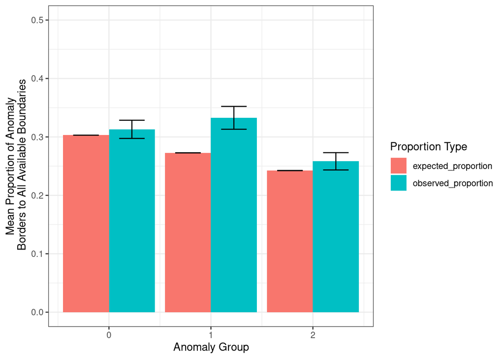

```r
anova_data %>%
  group_by(anomaly_group, proportion_type) %>%
  summarize(mean_proportion = mean(proportion), se = sd(proportion) / sqrt(length(unique(trial_summary$participant)))) %>%
  ggplot(aes(x = anomaly_group, y = mean_proportion)) +
  geom_bar(stat = 'identity', aes(fill = proportion_type), position = position_dodge(width = .9)) +
  geom_errorbar(aes(ymin = mean_proportion - se, ymax = mean_proportion + se, group = proportion_type), position = position_dodge(width = .9), width = .5) +
  ylim(0, .5) +
  labs(
    x = 'Anomaly Group',
    y = 'Mean Proportion of Anomaly\n Borders to All Available Boundaries',
    fill = 'Proportion Type'
  ) +
  theme_bw()
```

## Anomalies and biases

Doing a basic check to see whether the anomaly groups are disproportionately distributed along the quadrants or line orientations.

```python
import pickle

with open('contiguous_dict.pickle', 'rb') as file:
  contiguous_dict = pickle.load(file)

d1 = []
d2 = []

for key in contiguous_dict:
  d1 += [key] * 10
  d2 += contiguous_dict[key]

contiguous = pd.DataFrame({'anomaly_lines': d1, 'contiguous_lines': d2})
```

```r
## merge in group number
contiguous <- py$contiguous
group_summary <- trial_summary %>%
  group_by(anomaly_line_id) %>%
  summarize(anomaly_group = unique(anomaly_group))
colnames(group_summary)[1] <- 'anomaly_lines'
contiguous <- contiguous %>%
  inner_join(group_summary)
head(contiguous)
```

|  | anomaly_lines | contiguous_lines | anomaly_group |
| --- | --- | --- | --- |
| 1 | r0c1_bottom_right | r1c0_right | 2 |
| 2 | r0c1_bottom_right | r1c1_bottom_left | 2 |
| 3 | r0c1_bottom_right | r1c1_bottom_right | 2 |
| 4 | r0c1_bottom_right | r1c1_right | 2 |
| 5 | r0c1_bottom_right | r0c2_bottom_left | 2 |
| 6 | r0c1_bottom_right | r0c1_right | 2 |

```r
## merge in exterior information
exterior_summary <- line_data %>%
  mutate(center_x = (top_x + bottom_x) / 2, center_y = (top_y + bottom_y) / 2) %>%
  group_by(line_id) %>%
  summarize(is_exterior = unique(is_exterior), center_x = unique(center_x), center_y = unique(center_y), line_orientation = unique(line_orientation))
colnames(exterior_summary)[1] <- 'contiguous_lines'
contiguous <- contiguous %>%
  inner_join(exterior_summary)
head(contiguous)
```

|  | anomaly_lines | contiguous_lines | anomaly_group | is_exterior | center_x | center_y | line_orientation |
| --- | --- | --- | --- | --- | --- | --- | --- |
| 1 | r0c1_bottom_right | r1c0_right | 2 | False | -106.894851 | 150.32666 | vertical |
| 2 | r0c1_bottom_right | r1c1_bottom_left | 2 | False | -58.043992 | 55.48999 | back_slash |
| 3 | r0c1_bottom_right | r1c1_bottom_right | 2 | False | 39.657724 | 55.48999 | forward_slash |
| 4 | r0c1_bottom_right | r1c1_right | 2 | False | 88.508582 | 150.32666 | vertical |
| 5 | r0c1_bottom_right | r0c2_bottom_left | 2 | False | 39.657724 | 245.16333 | back_slash |
| 6 | r0c1_bottom_right | r0c1_right | 2 | False | -9.193134 | 340.00000 | vertical |

```r
## get quadrants
top_left <- c(min(line_data$top_x), max(line_data$top_y))
top_right <- c(max(line_data$top_x), max(line_data$top_y))
bottom_left <- c(min(line_data$bottom_x), min(line_data$bottom_y))
bottom_right <- c(max(line_data$bottom_x), min(line_data$bottom_y))
center <- c(mean(c(top_left[1], top_right[1])), mean(c(top_left[2], bottom_left[2])))

contiguous <- contiguous %>%
  mutate(quadrant = ifelse(center_x > center[1] & center_y > center[2], 'I', ifelse(center_x < center[1] & center_y > center[2], 'II',
                    ifelse(center_x < center[1] & center_y < center[2], 'III', ifelse(center_x > center[1] & center_y < center[2], 'IV', '')))),
         xdist = abs(center_x - center[1]),
         ydist = abs(center_y - center[2])) %>%
  mutate(is_on_axis = ifelse(xdist < 0.1, 'y_axis', ifelse(ydist < 0.1, 'x_axis', ''))) %>%
  mutate(quadrant = ifelse(is_on_axis == '', quadrant, is_on_axis)) %>%
  select(-center_x, -center_y, xdist, ydist)
```

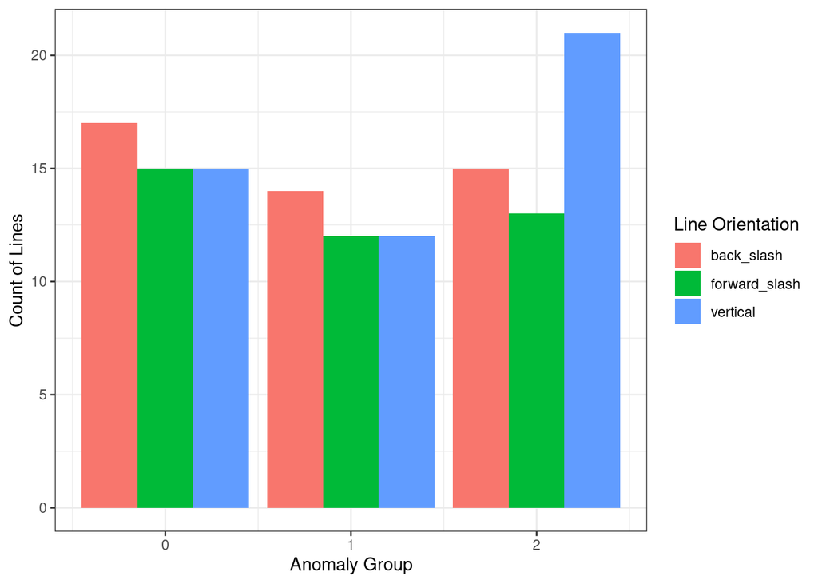

```r
## line orientation
contiguous %>%
  filter(is_exterior == 'False') %>%
  group_by(anomaly_group, line_orientation) %>%
  summarize(count = n()) %>%
  ggplot(aes(x = anomaly_group, y = count)) +
  geom_bar(stat = 'identity', aes(fill = line_orientation), position = position_dodge(width = .9)) +
  labs(
    x = 'Anomaly Group',
    y = 'Count of Lines',
    fill = 'Line Orientation'
  ) +
  theme_bw()
```

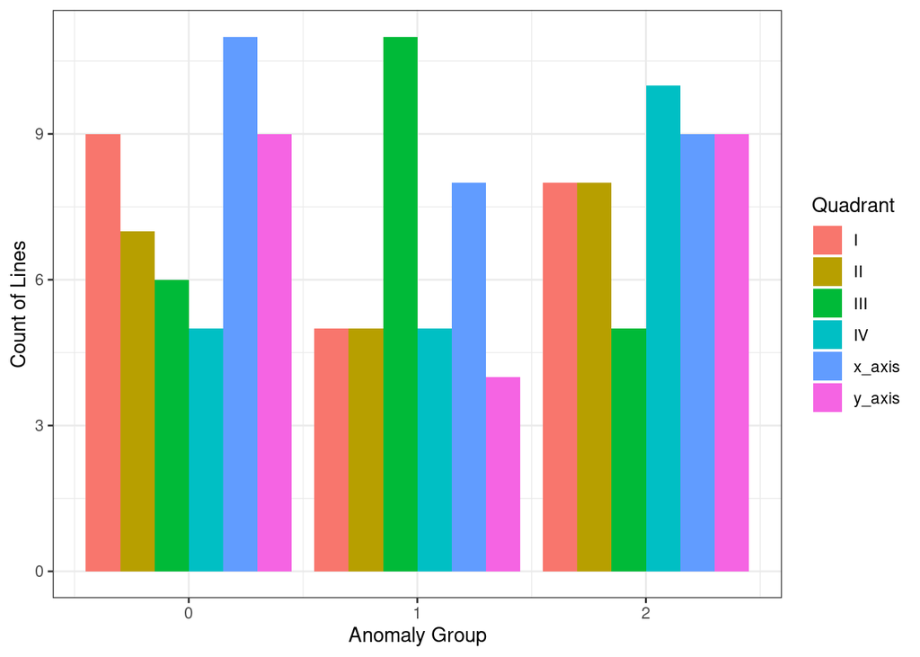

```r
## quadrant
contiguous %>%
  filter(is_exterior == 'False') %>%
  group_by(anomaly_group, quadrant) %>%
  summarize(count = n()) %>%
  ggplot(aes(x = anomaly_group, y = count)) +
  geom_bar(stat = 'identity', aes(fill = quadrant), position = position_dodge(width = .9)) +
  labs(
    x = 'Anomaly Group',
    y = 'Count of Lines',
    fill = 'Quadrant'
  ) +
  theme_bw()
```

A work by [Dave Braun](https://davebraun.net)

*dab414@lehigh.edu*